# Downstream analysis of Cholangiocarcinoma genomics and clinical data

Nasim Bondar Sahebi

2023-12-20

# Load Libraries

```r
library(SummarizedExperiment)
library(dplyr)
library(ggplot2)
library(knitr)
library(DT)
library(limma)
library(EnhancedVolcano)
library(fgsea)
library(msigdbr)
library(gage)
library(pathview)
```

# Data Loading and Preparation

#### Data Overview

Load the Summarized Experiment data object, extract clinical information, log-transformed TPM (Transcripts Per Million) expression data, along with annotations. Prepare the gene expression data for analysis.

```r
# Load your SE result and extract clinical data , expression data and annotation

# Load SE obj
se <- readRDS("~/BHK lab/kevin Project/Cholangiocarcinoma/output data/SE_CCA.rds")

# Extract Clinical data
clin <- data.frame(colData(se)) #dim is 33 x 11

# Extract the expression data
expr_tpm <- assays(se)[["expr_tpm"]] #dim 38040 x 33

# Extract the annotation
annot <- data.frame(rowData(se))  #dim is 38040 x 11

# Display first few rows of the dataset
DT::datatable(round(expr_tpm[1:8, 1:8], 3))
```

|  | BTC_0004 | BTC_0009 | BTC_0010 | BTC_0011 | BTC_0012 | BTC_0013 | BTC_0014 | BTC_0015 |
| --- | --- | --- | --- | --- | --- | --- | --- | --- |
| A1BG | 1.067 | 2.455 | 0.821 | 3.674 | 0.693 | 0.921 | 0 | 0.712 |
| A1BG-AS1 | 0 | 0.6 | 1.494 | 2.005 | 0.054 | 0.795 | 0 | 0.419 |
| A1CF | 2.035 | 4.8 | 4.489 | 1.876 | 2.086 | 0.557 | 0 | 3.45 |
| A2M | 6.053 | 5.403 | 4.396 | 7.086 | 4.524 | 6.12 | 6.114 | 6.785 |
| A2M-AS1 | 0.062 | 0.57 | 0.969 | 1.406 | 1.392 | 0.437 | 0 | 0.163 |
| A2ML1 | 4.446 | 0.03 | 0.226 | 3.42 | 0.797 | 3.265 | 0 | 0.072 |
| A2ML1-AS1 | 0 | 0 | 0 | 0 | 0 | 0.33 | 0 | 0 |
| A2ML1-AS2 | 0 | 0 | 0 | 0 | 0 | 0 | 0 | 0 |

# Data Preparation

Preparing expression data (RNA-seq) for analysis:

1. Restrict expression data to protein-coding genes.
2. Remove low/zero expression genes.

Total 16,256 genes remain for downstream analyses.

```r
# Step 1: Restrict to Protein-Coding Genes.
annot_proteincoding <- annot[annot$gene_type == "protein_coding",] # 19205 protein coding genes.
expr_tpm<- expr_tpm[rownames(expr_tpm) %in% rownames(annot_proteincoding),]
dim(expr_tpm)
```

```
## [1] 19205    33
```

```r
# Step 2: Filter Low/Zero Expression Genes]

#data is log2(TPM+1)
r <- as.numeric(apply(expr_tpm, 1, function(i) sum(round(i, 6) == round(log2(1), 6))))

# Get the indices of rows to remove
remove <- which(r > dim(expr_tpm)[2] * 0.5)

# Remove rows from the matrix
expr_tpm <- expr_tpm[-remove, ]   #dim is 16256 x 33

DT::datatable(round(expr_tpm[1:8, 1:8], 3))
```

|  | BTC_0004 | BTC_0009 | BTC_0010 | BTC_0011 | BTC_0012 | BTC_0013 | BTC_0014 | BTC_0015 |
| --- | --- | --- | --- | --- | --- | --- | --- | --- |
| A1BG | 1.067 | 2.455 | 0.821 | 3.674 | 0.693 | 0.921 | 0 | 0.712 |
| A1CF | 2.035 | 4.8 | 4.489 | 1.876 | 2.086 | 0.557 | 0 | 3.45 |
| A2M | 6.053 | 5.403 | 4.396 | 7.086 | 4.524 | 6.12 | 6.114 | 6.785 |
| A2ML1 | 4.446 | 0.03 | 0.226 | 3.42 | 0.797 | 3.265 | 0 | 0.072 |
| A4GALT | 1.305 | 3.065 | 3.887 | 3.277 | 5.143 | 4.181 | 4.494 | 4.473 |
| A4GNT | 0.502 | 1.605 | 0.462 | 5.638 | 0.154 | 1.8 | 0 | 0 |
| AAAS | 5.85 | 4.916 | 4.313 | 4.476 | 5.71 | 4.489 | 0 | 4.096 |
| AACS | 5.183 | 4.262 | 4.631 | 4.72 | 5.444 | 5.043 | 3.853 | 3.776 |

# Descriptive analysis

## Evaluate Differences in Clinicodemographic and Staging Variables

- **Continuous Variables (e.g., Age):** Calculated the median and IQR and assessed associations using the Wilcoxon test.
- **Discrete/Categorical Variables (e.g., Sex, Stage, Location):** Determined frequency and percentage distributions and assessed associations using Fisher’s exact test.

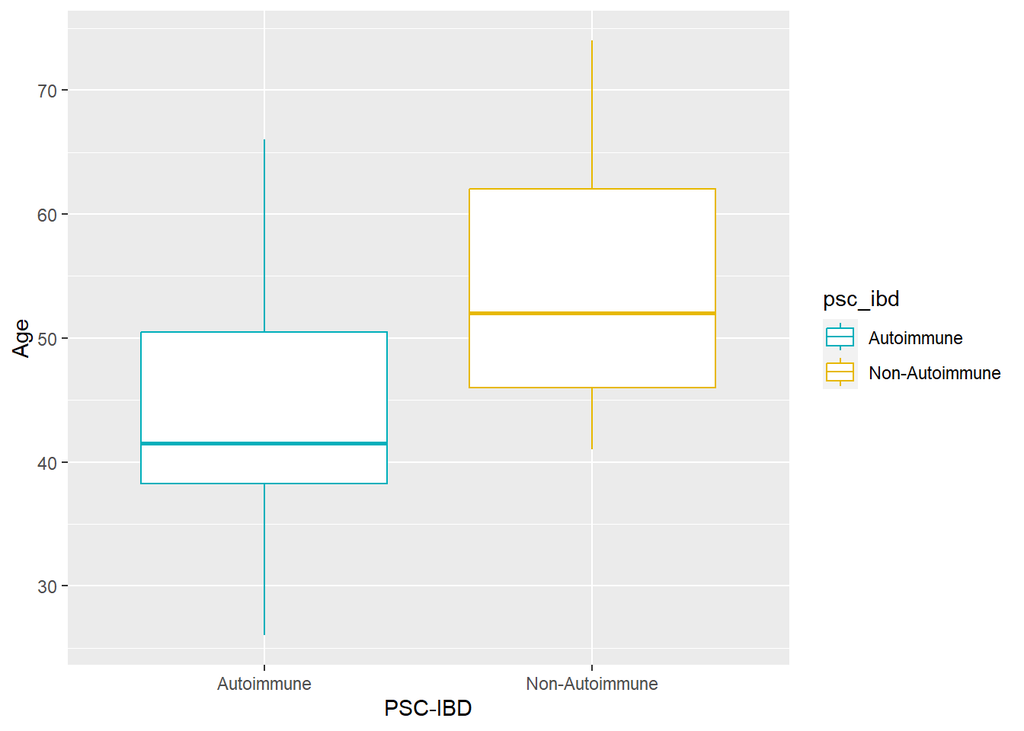

```r
# Set 'y' and 'n' to 'Autoimmune' and 'Non-Autoimmune' within the dataframe
clin$psc_ibd[clin$psc_ibd == 'y'] <- 'Autoimmune'
clin$psc_ibd[clin$psc_ibd == 'n'] <- 'Non-Autoimmune'

# 1. Age

# Summarize age statistics (count,Mean(SD), Median(IQR), Min,Max) for each psc_ibd group.
summary_stats <- summarise(
  group_by(clin, psc_ibd),
  count = n(),
  Mean_SD = sprintf("%.2f(%.2f)", mean(age, na.rm = TRUE), sd(age, na.rm = TRUE)),
  Median_IQR = sprintf("%.2f(%.2f)", median(age, na.rm = TRUE), IQR(age, na.rm = TRUE)),
  Min_Max = sprintf("%.2f,%.2f", min(age, na.rm = TRUE), max(age, na.rm = TRUE))
)

# Store statistics for Auto and Non-Auto for later use
auto_count <- summary_stats$count[summary_stats$psc_ibd == "Autoimmune"]
non_auto_count <- summary_stats$count[summary_stats$psc_ibd == "Non-Autoimmune"]

# Visualize your data.

# Plotting boxplot for age distributions
ggplot(clin, aes(x = psc_ibd, y = age, color = psc_ibd)) +
  geom_boxplot() +
  scale_color_manual(values = c("Autoimmune" = "#00AFBB", "Non-Autoimmune" = "#E7B800")) +
  labs(y = "Age", x = "PSC-IBD")
```

```r
# Perform two-sample Wilcoxon test
res <- wilcox.test(age ~ psc_ibd, data = clin, exact = FALSE)
p_value_age <- round(res$p.value, 2)

# 2. Sex

# Perform Fisher's Exact Test for 'sex' and 'psc_ibd'
contingency_sex <- table(clin$sex, clin$psc_ibd)
p_value_sex <- round(fisher.test(contingency_sex)$p.value,2)

# Calculate and format percentages for Sex
sex_stats <- apply(contingency_sex, 2, function(x) sprintf("%d (%.1f%%)", x, 100 * x / sum(x)))

# Perform Fisher's Exact Test for 'location' and 'psc_ibd'
contingency_loc <- table(clin$location, clin$psc_ibd)
p_value_loc <- round(fisher.test(contingency_loc)$p.value, 2)

# Calculate and format percentages for Location
location_stats <- apply(contingency_loc, 2, function(x) sprintf("%d (%.1f%%)", x, 100 * x / sum(x)))

# Perform Fisher's Exact Test for 'stage' and 'psc_ibd'
# Convert "IIIA", "IIIB", "IIIC" to "III and convert "IVA", "IVB" to "IV".
clin$stage <- with(clin, ifelse(stage %in% c("IIIA", "IIIB", "IIIC"), "III",
                                ifelse(stage %in% c("IVA", "IVB"), "IV", stage)))

contingency_stage <- table(clin$stage, clin$psc_ibd)
p_value_stage <- round(fisher.test(contingency_stage)$p.value, 2)


# Calculate and format percentages for Stage
stage_stats <- apply(contingency_stage, 2, function(x) sprintf("%d (%.1f%%)", x, 100 * x / sum(x)))


# Combine all statistics into a data frame for the table
result <- data.frame(
  Characteristics = c("Age", "Mean (SD)", "Median (IQR)", "Min, Max", "",
                      "Sex", "F", "M", "","Location", "dCCA", "GBC", "iCCA",
                      "pCCA", "", "Stage", "II", "III", "IV"),

  `Autoimmune (n=14)` = c("", summary_stats$Mean_SD[1], summary_stats$Median_IQR[1], summary_stats$Min_Max[1],
                          "","",sex_stats[1, 1], sex_stats[2, 1], "", "", location_stats[1, 1],
                          location_stats[2, 1], location_stats[3, 1], location_stats[4, 1],"","",
                          stage_stats[1, 1], stage_stats[2, 1], stage_stats[3, 1]),

  `Non-Autoimmune (n=19)` = c("", summary_stats$Mean_SD[2], summary_stats$Median_IQR[2],summary_stats$Min_Max[2],
                              "","", sex_stats[1, 2], sex_stats[2, 2], "", "", location_stats[1, 2],
                              location_stats[2, 2],location_stats[3, 2], location_stats[4, 2],"","",
                              stage_stats[1, 2], stage_stats[2, 2],stage_stats[3, 2]),

  `P value` = c(p_value_age, "", "", "", "",
                p_value_sex, "", "", "", p_value_loc,
                "", "", "", "", "",p_value_stage, "", "", ""),

  check.names = FALSE
)


table_html <- kable(
    result,
    format = "html",
    caption =" Table 1: Clinicodemographic and Staging Characteristics at Baseline (AJCC 8th Edition)",
    escape = FALSE,
    table.attr = 'style="width:100%; overflow-x:scroll; overflow-y:scroll; max-height:400px;"'
)

table_html
```

Table 1: Clinicodemographic and Staging Characteristics at Baseline (AJCC 8th Edition)

| Characteristics | Autoimmune (n=14) | Non-Autoimmune (n=19) | P value |
| --- | --- | --- | --- |
| Age |  |  | 0.01 |
| Mean (SD) | 43.57(10.68) | 54.68(10.91) |  |
| Median (IQR) | 41.50(12.25) | 52.00(16.00) |  |
| Min, Max | 26.00,66.00 | 41.00,74.00 |  |
| Sex |  |  | 0.28 |
| F | 3 (21.4%) | 8 (42.1%) |  |
| M | 11 (78.6%) | 11 (57.9%) |  |
| Location |  |  | 0.02 |
| dCCA | 0 (0.0%) | 1 (5.3%) |  |
| GBC | 1 (7.1%) | 3 (15.8%) |  |
| iCCA | 8 (57.1%) | 15 (78.9%) |  |
| pCCA | 5 (35.7%) | 0 (0.0%) |  |
| Stage |  |  | 0.52 |
| II | 5 (35.7%) | 8 (42.1%) |  |
| III | 4 (28.6%) | 2 (10.5%) |  |
| IV | 5 (35.7%) | 9 (47.4%) |  |

# Differential gene expression.

- **Use limma approach in R** : To find the differentially expressed genes between Autoimmune and Non-Autoimmune.
- **P-values are corrected to control false discovery rate (FDR)** using Benjamini-Hochberg approach
- **out put:** Limma_Fit.txt file

```r
# Limma approach applied.
design <- model.matrix(~ clin$psc_ibd)
fit <- lmFit(expr_tpm, design)
fit <- eBayes(fit)

# Sort by Pvalue.
top.table <- topTable(fit, sort.by = "P", n = Inf)

# To see How many DE gene are there.
length(which(top.table$adj.P.Val < 0.05))  # 460 DE genes.
```

```
## [1] 460
```

```r
# Preview
DT::datatable(data.frame(round(data.frame(top.table),3)))
```

|  | logFC | AveExpr | t | P.Value | adj.P.Val | B |
| --- | --- | --- | --- | --- | --- | --- |
| EML1 | 1.866 | 2.448 | 6.546 | 0 | 0.001 | 7.191 |
| ITGA6 | -1.73 | 6.159 | -6.485 | 0 | 0.001 | 7.026 |
| NR1H4 | 2.824 | 3.296 | 6.34 | 0 | 0.001 | 6.632 |
| RERG | 2.336 | 2.769 | 6.326 | 0 | 0.001 | 6.595 |
| TRABD2B | 1.758 | 1.681 | 6.224 | 0 | 0.001 | 6.316 |
| LIMCH1 | 3.364 | 4.422 | 6.092 | 0 | 0.001 | 5.958 |
| SHISA4 | 2.015 | 2.348 | 6.027 | 0 | 0.001 | 5.781 |
| EPOR | 1.838 | 2.757 | 6.012 | 0 | 0.001 | 5.74 |
| UNC5CL | 2.583 | 4.115 | 5.998 | 0 | 0.001 | 5.701 |
| PTPRS | 2.683 | 3.698 | 5.854 | 0 | 0.002 | 5.307 |

[output cut: 16246 more lines]

```r
# Save top table to .txt file.
top.table$Gene <- rownames(top.table)
write.table(top.table, file = "~/BHK lab/kevin Project/Cholangiocarcinoma/output data/Limma_Fit.txt", row.names = F, sep = "\t", quote = F)
```

## Volcano plot

- **Volcano Plot:** based on P value and FDR

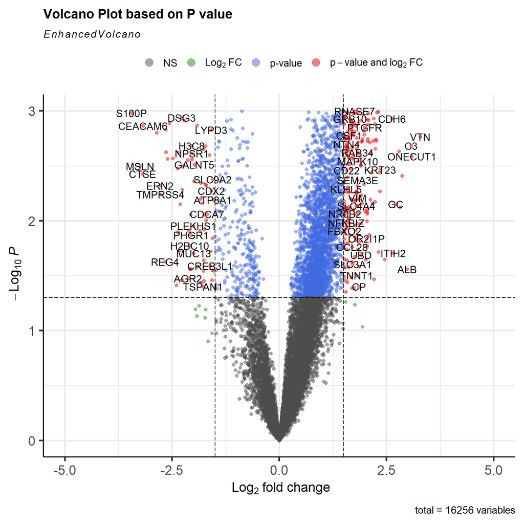

```r
# 1. Volcano plot.

# 1.1 Volcano Plot based on P value
EnhancedVolcano(top.table,
    lab = rownames(top.table),
    x = 'logFC',
    y = 'P.Value',
    pCutoff = 0.05,
    FCcutoff = 1.5,
    xlim = c(-5, 5),
    ylim = c(0, -log10(10e-4)),
    title= 'Volcano Plot based on P value'
    )
```

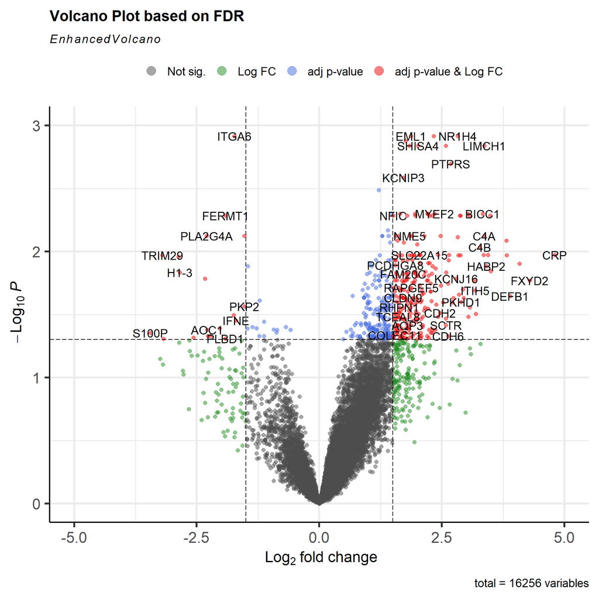

```r
# 1.2 Volcano Plot based on FDR
# adjusted p-values as red
EnhancedVolcano(top.table,
    lab = rownames(top.table),
    x = 'logFC',
    y = 'adj.P.Val',
    pCutoff = 0.05,
    FCcutoff = 1.5,
    xlim = c(-5, 5),
    ylim = c(0, -log10(10e-4)),
    legendLabels=c('Not sig.','Log FC','adj p-value',
      'adj p-value & Log FC'),
    title= 'Volcano Plot based on FDR',)
```

# MSigDB Pathway analysis

- To Identify the associated pathways or genes sets.
- Downloaded hallmark(H) , KEGG gene sets from [MSigDB website](https://www.gsea-msigdb.org/gsea/msigdb/human/collections.jsp#H).
- Conduct GSEA with the fgsea package using “top.table” from step 2.

## Hallmark Geneset.

```r
# Load human hallmark gene sets from MSigDB
pathwaysDF <- msigdbr("Homo sapiens", category="H")

# Create a list of gene symbols for each pathway
pathwaysH <- split(as.character(pathwaysDF$gene_symbol), pathwaysDF$gs_name)

# 1. Create ranks

# Create 'ranks' vector from 'top.table' with logFC as values and gene names as names.
ranks <- top.table$logFC
names(ranks) <- top.table$Gene
ranks <- sort(ranks, decreasing = T)

# Preview the data table of ranks.
DT::datatable(data.frame(ranks))
```

|  | ranks |
| --- | --- |
| CRP | 4.802662489523767 |
| FXYD2 | 4.295339082111421 |
| SERPINA1 | 4.084982367119603 |
| DEFB1 | 3.89505313075676 |
| APCS | 3.822964991782735 |
| AGT | 3.813100281801923 |
| SPP1 | 3.499643175876602 |
| SERPINA6 | 3.485172553665544 |
| HPN | 3.438429283568876 |
| HABP2 | 3.407576577036006 |

[output cut: 16246 more lines]

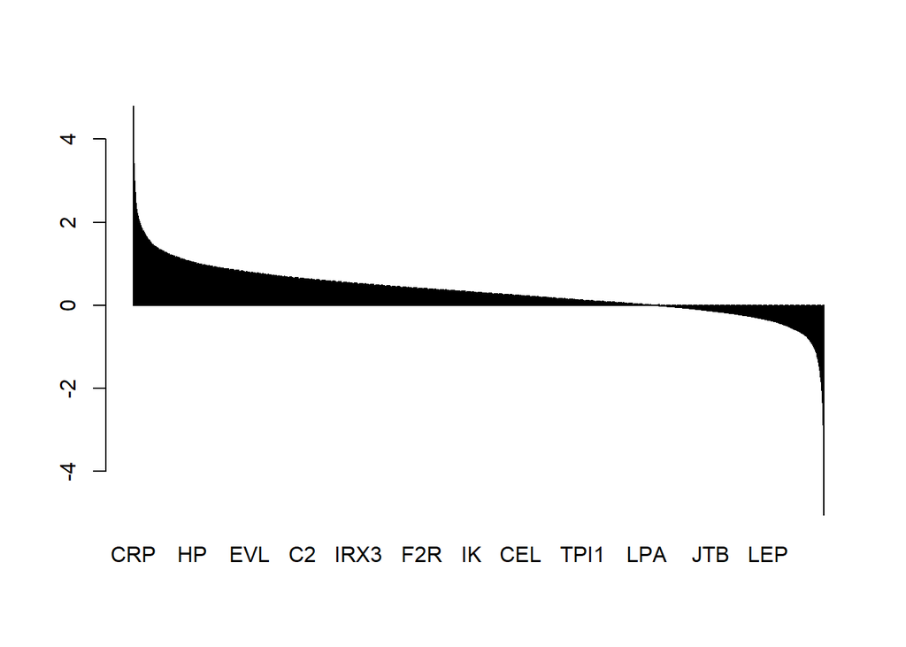

```r
# 2. Bar Plot
# Display the ranked fold changes.
barplot(ranks)
```

```r
# 3. Conduct analysis
# Run fgsea with 'pathwaysH' and 'ranks'.
fgseaRes <- fgsea(pathwaysH, ranks)
fgseaRes <- na.omit(fgseaRes)

fgseaResTidy <- fgseaRes %>%
  as_tibble() %>%
  arrange(desc(NES)) #order by NES

# Combine genes in leadingEdge with semicolons
fgseaResTidy$leadingEdge <- sapply(fgseaResTidy$leadingEdge, paste, collapse = ";")
fgseaResTidy <- fgseaResTidy[order(fgseaResTidy$padj), ]

# Show in a Tidy table.
head(fgseaResTidy)
```

```
## # A tibble: 6 × 8
##   pathway                     pval    padj log2err    ES   NES  size leadingEdge
##   <chr>                      <dbl>   <dbl>   <dbl> <dbl> <dbl> <int> <chr>
## 1 HALLMARK_INTERFERON_GAM… 5.64e-6 2.59e-4   0.611 0.466  1.55   199 CFB;IFIT2;…
## 2 HALLMARK_EPITHELIAL_MES… 1.19e-5 2.73e-4   0.593 0.460  1.53   199 SPP1;CXCL6…
## 3 HALLMARK_INTERFERON_ALP… 4.34e-5 6.65e-4   0.557 0.511  1.64    97 IFIT2;IFIT…
## 4 HALLMARK_COAGULATION     7.53e-5 8.66e-4   0.538 0.486  1.59   129 SERPINA1;H…
## 5 HALLMARK_TNFA_SIGNALING… 3.49e-4 2.74e-3   0.498 0.436  1.46   198 CXCL2;CXCL…
## 6 HALLMARK_OXIDATIVE_PHOS… 3.58e-4 2.74e-3   0.498 0.433  1.44   200 LDHB;MAOB;…
```

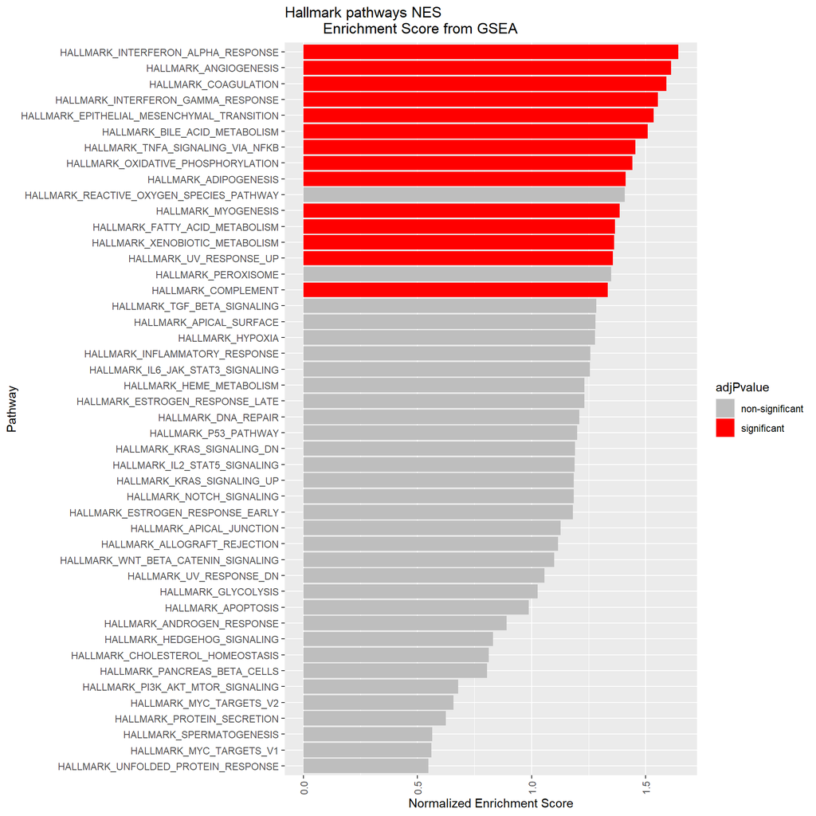

```r
# Save fgseaRes as txt file.
write.table(fgseaResTidy, "~/BHK lab/kevin Project/Cholangiocarcinoma/output data/fgseaRes_HRank.txt", sep = "\t", row.names = FALSE, quote = FALSE)

# Mark "significant" if adjusted p-value <= 0.05, else "non-significant".
fgseaResTidy$adjPvalue <- ifelse(fgseaResTidy$padj <= 0.05, "significant", "non-significant")

# Define colors for significance: grey for non-significant and red for significant results.
cols <- c("non-significant" = "grey", "significant" = "red")

# Using ggplot: reorder pathways by NES, fill bars based on significance, flip coordinates for readability.
ggplot(fgseaResTidy, aes(reorder(pathway, NES), NES, fill = adjPvalue)) + geom_col() +
    scale_fill_manual(values = cols) + coord_flip() +
    theme(axis.text.x = element_text(angle = 90, vjust = 0.5, hjust=1)) +
    labs(x = "Pathway", y = "Normalized Enrichment Score", title = "Hallmark pathways NES
         Enrichment Score from GSEA")
```

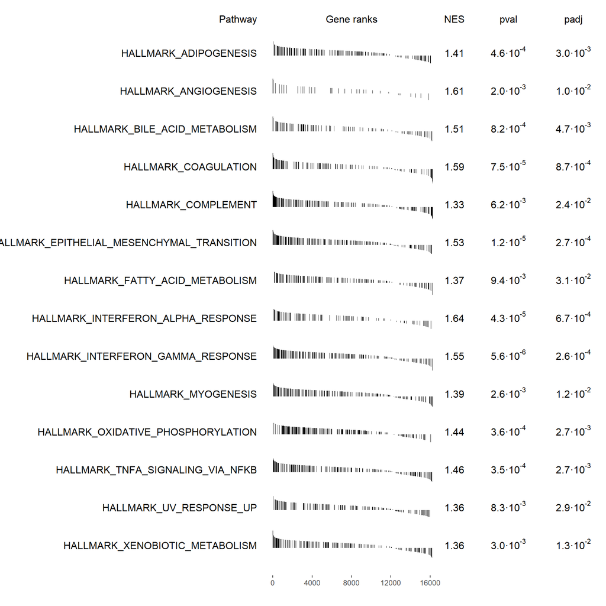

```r
# 4. GSEA Results Table Plot.
# Plot GSEA table for significant pathways (padj < 0.05) using a GSEA parameter of 0.5.
plotGseaTable(pathwaysH[fgseaRes$pathway[fgseaRes$padj < 0.05]], ranks, fgseaRes, gseaParam=0.5)
```

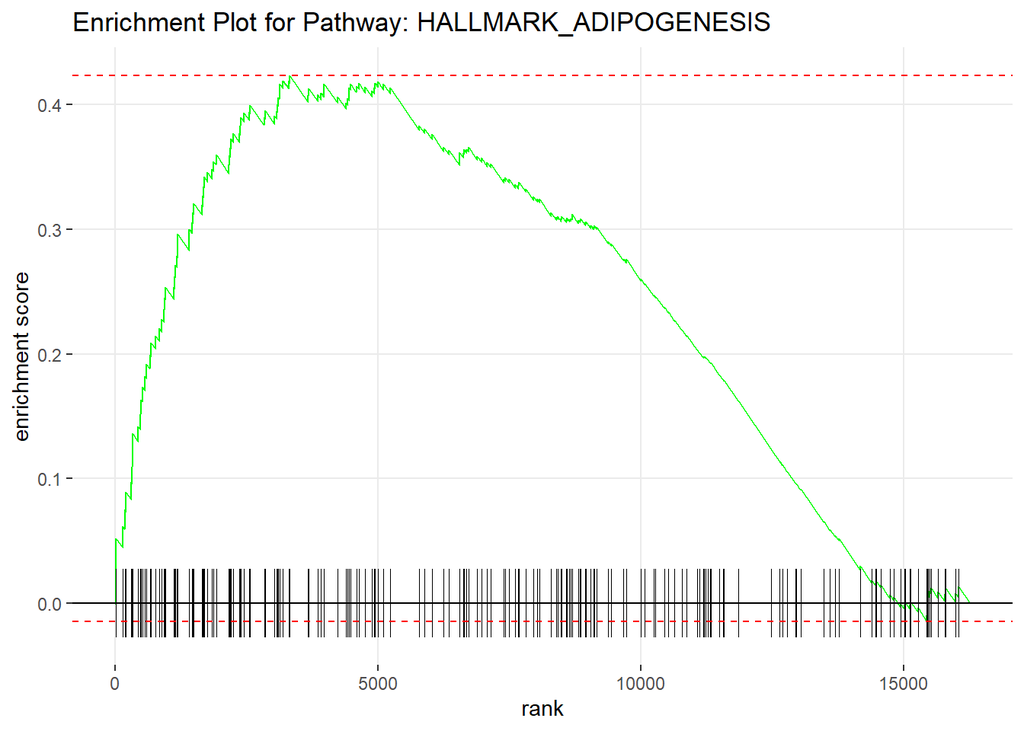

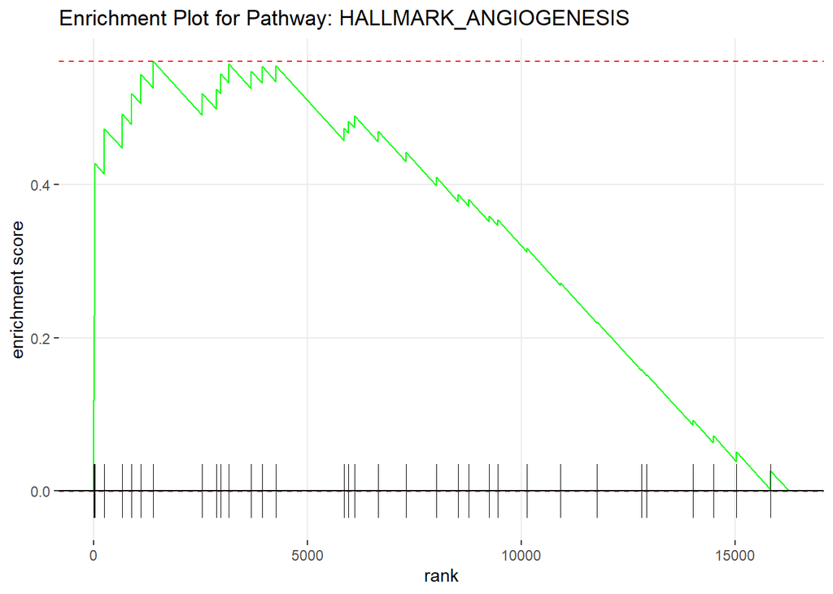

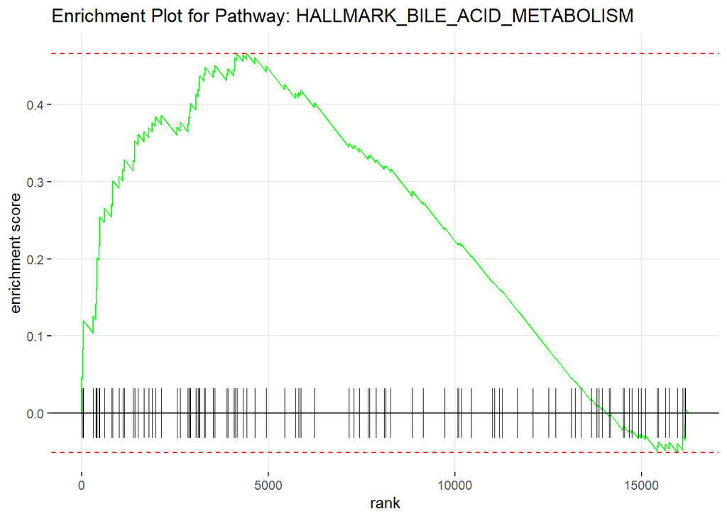

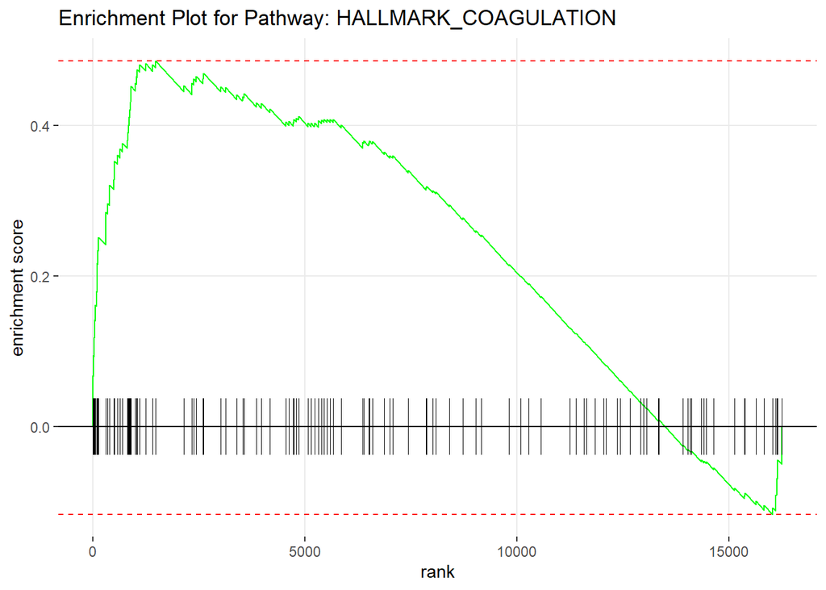

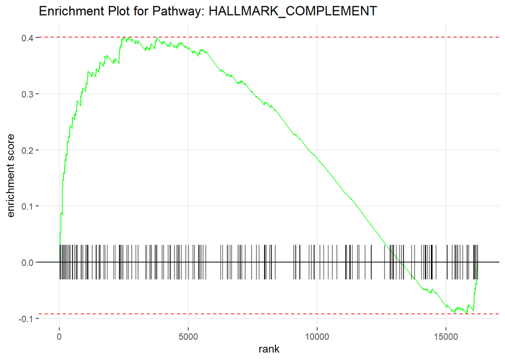

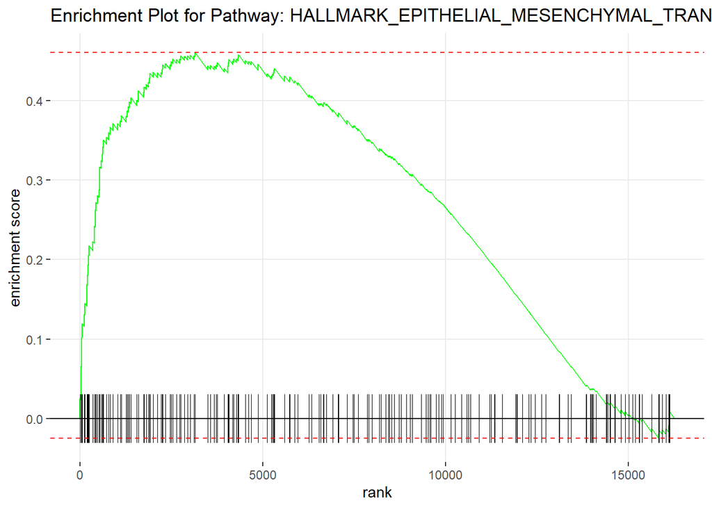

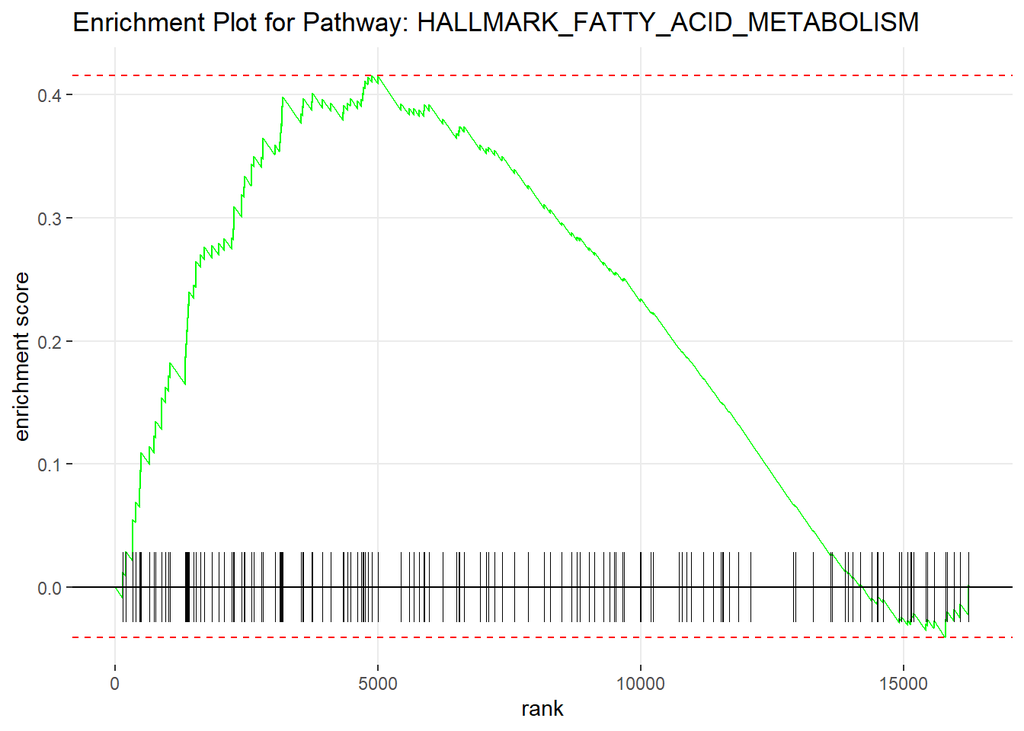

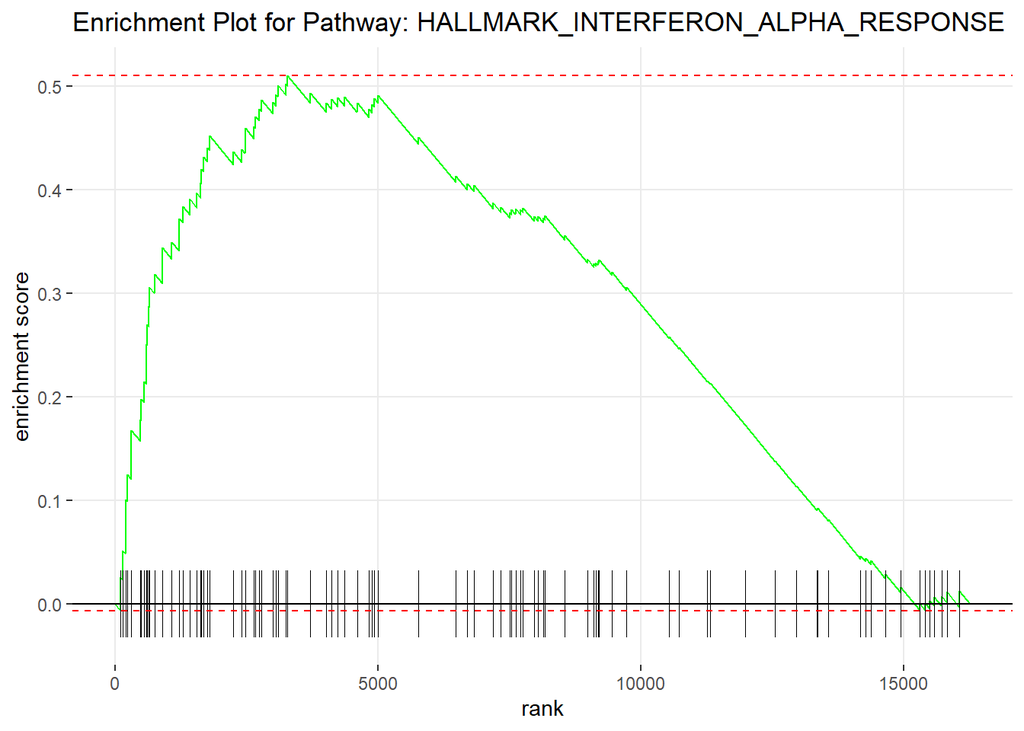

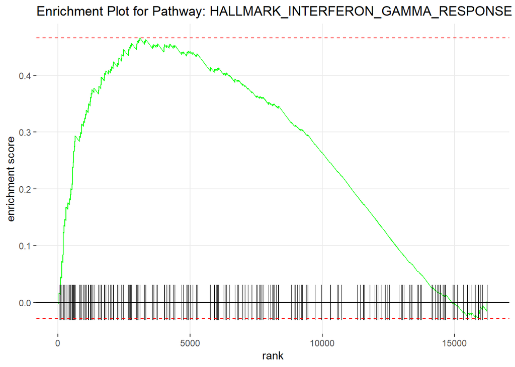

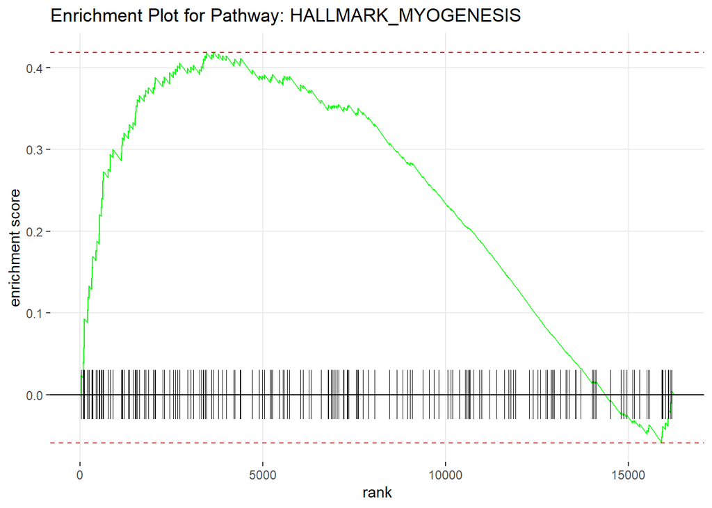

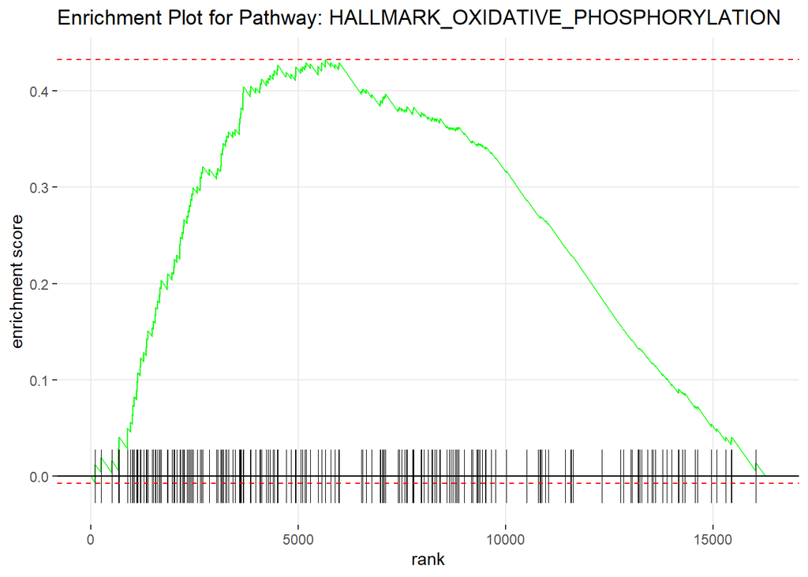

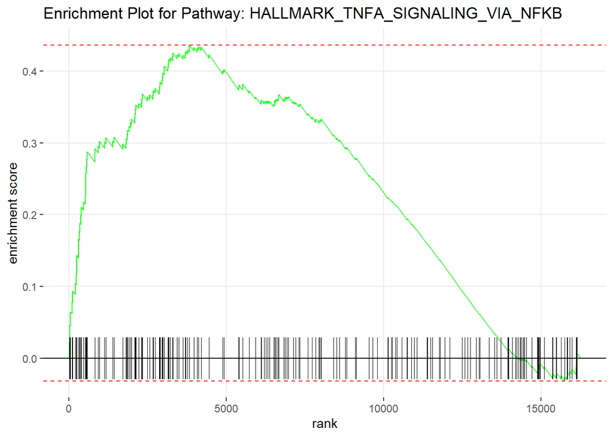

[2 more figures not shown]

```r
# 5.  Enrichment score plot.

# For significant pathways # 14 pathways.

# Store the list of significant pathways (padj < 0.05).
significant_pathways <- fgseaRes$pathway[fgseaRes$padj < 0.05]

# Use a for loop to iterate and plot enrichment for each significant pathway
for (i in significant_pathways) {
  enrichment_plot <- plotEnrichment(pathwaysH[[i]], ranks)
  enrichment_plot <- enrichment_plot + ggtitle(paste("Enrichment Plot for Pathway:",i))
  print(enrichment_plot)
}
```

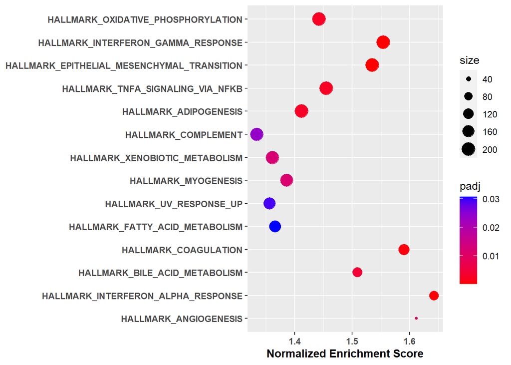

```r
# Plot significant pathways as points with a gradient color based on p-value and size based on a 'size' variable.
ggplot(fgseaResTidy[fgseaResTidy$padj < 0.05, ], aes(y=reorder(pathway, size),x= NES)) + geom_point(aes(color=padj,size=size)) +
  scale_color_gradientn(colours = c("red","blue")) +
  labs(x='Normalized Enrichment Score', y=NULL ) +
  theme( axis.title = element_text(face='bold'), axis.text = element_text (face='bold') )
```

## KEGG Pathway Analysis

To do KEGG pathway analysis, both KEGG_MEDICUS and KEGG_LEGACY are downloaded. The cutoff of 0.05 is applied for visualization, while the text files include the results across all gene sets.

### KEGG_MEDICUS

186 canonical pathways gene sets derived from the KEGG MEDICUS pathway database.

```r
# Load KEGG_MEDICUS pathways.
pathwaysKEG <- gmtPathways("~/BHK lab/kevin Project/Cholangiocarcinoma/GSEA/c2.cp.kegg_medicus.v2023.2.Hs.symbols.gmt")

# Perform fgsea with KEGG pathways
fgseaRes_kegg <- fgsea(pathwaysKEG, ranks)

# Organize and sort KEGG results by NES
fgseaResTidy_kegg <- fgseaRes_kegg %>%
  as_tibble() %>%
  arrange(desc(NES))

# Combine genes in leadingEdge with semicolons
fgseaResTidy_kegg$leadingEdge <- sapply(fgseaResTidy_kegg$leadingEdge, paste, collapse = ";")

# Show in a Tidy table of keg.
head(fgseaResTidy_kegg)
```

```
## # A tibble: 6 × 8
##   pathway                     pval    padj log2err    ES   NES  size leadingEdge
##   <chr>                      <dbl>   <dbl>   <dbl> <dbl> <dbl> <int> <chr>
## 1 KEGG_MEDICUS_REFERENCE_… 2.48e-5 0.00257   0.576 0.893  1.91     8 C4A;C4B;C1…
## 2 KEGG_MEDICUS_REFERENCE_… 7.56e-5 0.00520   0.538 0.873  1.87     8 FGA;FGB;FG…
## 3 KEGG_MEDICUS_REFERENCE_… 3.02e-5 0.00267   0.576 0.932  1.83     6 SERPING1;C…
## 4 KEGG_MEDICUS_VARIANT_MU… 1.72e-5 0.00257   0.576 0.618  1.83    45 NDUFB7;NDU…
## 5 KEGG_MEDICUS_VARIANT_MU… 1.72e-5 0.00257   0.576 0.618  1.83    45 NDUFB7;NDU…
## 6 KEGG_MEDICUS_REFERENCE_… 2.49e-5 0.00257   0.576 0.620  1.83    44 NDUFB7;NDU…
```

```r
# Save fgseaRes_keg as txt file.
write.table(fgseaResTidy_kegg, "~/BHK lab/kevin Project/Cholangiocarcinoma/output data/fgseaRes_kegRank.txt", sep = "\t", row.names = FALSE, quote = FALSE)
```

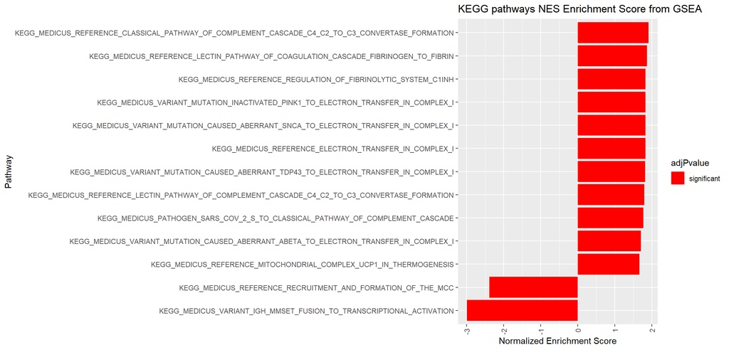

```r
# Mark "significant" if adjusted p-value <= 0.05, else "non-significant".
fgseaResTidy_kegg$adjPvalue <- ifelse(fgseaResTidy_kegg$padj <= 0.05, "significant", "non-significant")

# Create a ggplot of significant pathways, with bars colored based on adjusted p-value significance.
ggplot(fgseaResTidy_kegg[fgseaResTidy_kegg$padj < 0.05, ], aes(reorder(pathway, NES), NES, fill = adjPvalue)) +
  geom_col() +
  scale_fill_manual(values = cols) +
  coord_flip() +
  theme(axis.text.x = element_text(angle = 90, vjust = 0.5, hjust=1)) +
  labs(x = "Pathway", y = "Normalized Enrichment Score", title = "KEGG pathways NES Enrichment Score from GSEA")
```

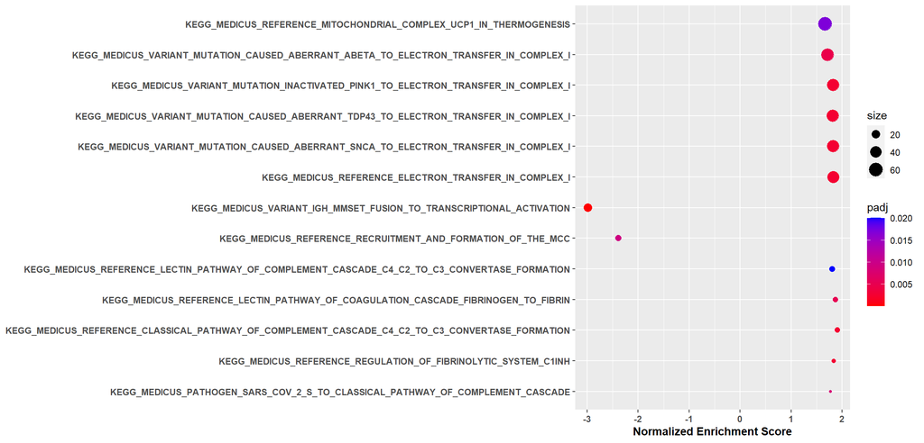

```r
# Plot significant pathways as points with a gradient color based on p-value and size based on a 'size' variable.
ggplot(fgseaResTidy_kegg[fgseaResTidy_kegg$padj < 0.05, ], aes(y=reorder(pathway, size),x= NES)) + geom_point(aes(color=padj,size=size)) +
  scale_color_gradientn(colours = c("red","blue")) +
  labs(x='Normalized Enrichment Score', y=NULL ) +
  theme( axis.title = element_text(face='bold'), axis.text = element_text (face='bold') )
```

```r
# Load KEGG_MEDICUS pathways.
pathwaysKEG_LEG <- gmtPathways("~/BHK lab/kevin Project/Cholangiocarcinoma/GSEA/c2.cp.kegg_legacy.v2023.2.Hs.symbols.gmt")

# Perform fgsea with KEGG pathways
fgseaRes_kegg <- fgsea(pathwaysKEG, ranks)

# Organize and sort KEGG results by NES
fgseaResTidy_kegg <- fgseaRes_kegg %>%
  as_tibble() %>%
  arrange(desc(NES))

# Combine genes in leadingEdge with semicolons
fgseaResTidy_kegg$leadingEdge <- sapply(fgseaResTidy_kegg$leadingEdge, paste, collapse = ";")

# Show in a Tidy table of keg.
head(fgseaResTidy_kegg)
```

```
## # A tibble: 6 × 8
##   pathway                     pval    padj log2err    ES   NES  size leadingEdge
##   <chr>                      <dbl>   <dbl>   <dbl> <dbl> <dbl> <int> <chr>
## 1 KEGG_MEDICUS_REFERENCE_… 5.08e-5 0.00449   0.557 0.893  1.90     8 C4A;C4B;C1…
## 2 KEGG_MEDICUS_REFERENCE_… 1.69e-4 0.00911   0.519 0.873  1.86     8 FGA;FGB;FG…
## 3 KEGG_MEDICUS_REFERENCE_… 1.42e-5 0.00263   0.593 0.620  1.84    44 NDUFB7;NDU…
## 4 KEGG_MEDICUS_REFERENCE_… 3.95e-5 0.00407   0.557 0.932  1.84     6 SERPING1;C…
## 5 KEGG_MEDICUS_VARIANT_MU… 1.70e-5 0.00263   0.576 0.618  1.83    45 NDUFB7;NDU…
## 6 KEGG_MEDICUS_VARIANT_MU… 1.70e-5 0.00263   0.576 0.618  1.83    45 NDUFB7;NDU…
```

```r
# Save fgseaRes_keg as txt file.
write.table(fgseaResTidy_kegg, "~/BHK lab/kevin Project/Cholangiocarcinoma/output data/fgseaRes_KEGGRank_legacy.txt", sep = "\t", row.names = FALSE, quote = FALSE)
```

[figure not shown]

```r
# Mark "significant" if adjusted p-value <= 0.05, else "non-significant".
fgseaResTidy_kegg$adjPvalue <- ifelse(fgseaResTidy_kegg$padj <= 0.05, "significant", "non-significant")


# Create a ggplot of significant pathways, with bars colored based on adjusted p-value significance.
ggplot(fgseaResTidy_kegg[fgseaResTidy_kegg$padj < 0.05, ], aes(reorder(pathway, NES), NES, fill = adjPvalue)) +
  geom_col() +
  scale_fill_manual(values = cols) +
  coord_flip() +
  theme(axis.text.x = element_text(angle = 90, vjust = 0.5, hjust=1)) +
  labs(x = "Pathway", y = "Normalized Enrichment Score", title = "KEGG (legacy) pathways NES Enrichment Score from GSEA")
```

[figure not shown]

```r
# Plot significant pathways as points with a gradient color based on p-value and size based on a 'size' variable.
ggplot(fgseaResTidy_kegg[fgseaResTidy_kegg$padj < 0.05, ], aes(y=reorder(pathway, size),x= NES)) + geom_point(aes(color=padj,size=size)) +
  scale_color_gradientn(colours = c("red","blue")) +
  labs(x='Normalized Enrichment Score', y=NULL ) +
  theme( axis.title = element_text(face='bold'), axis.text = element_text (face='bold') )
```

### Over-Representation Analysis analysis (ORA)

using fgsea package

```r
# ORA with fgsea

# we use 'top.table' from the differential expression analysis
# contains the list of genes of interest

# Set a vector of differentially expressed genes for ORA
de_genes <- rownames(top.table)[top.table$adj.P.Val < 0.05]  # genes with an adj p-value less than 0.05

# Defining the gene universe as all genes considered in the analysis
gene_universe <- rownames(expr_tpm)

## Performing ORA

# ORA for Hallmark pathways
ora_results_hallmark <- fora(pathways = pathwaysH, genes = de_genes, universe = gene_universe, minSize = 15, maxSize = 500)
ora_results_hallmark$Pathway_Set <- "Hallmark"
ora_results_hallmark$Significance <- ifelse(ora_results_hallmark$padj < 0.05, "Significant", "Not Significant")

# ORA for KEGG_MEDICUS pathways
ora_results_kegg_medicus <- fora(pathways = pathwaysKEG, genes = de_genes, universe = gene_universe, minSize = 15, maxSize = 500)
ora_results_kegg_medicus$Pathway_Set <- "KEGG_MEDICUS"
ora_results_kegg_medicus$Significance <- ifelse(ora_results_kegg_medicus$padj < 0.05, "Significant", "Not Significant")

# ORA for KEGG_LEGACY pathways
ora_results_kegg_legacy <- fora(pathways = pathwaysKEG_LEG, genes = de_genes, universe = gene_universe, minSize = 15, maxSize = 500)
ora_results_kegg_legacy$Pathway_Set <- "KEGG_LEGACY"
ora_results_kegg_legacy$Significance <- ifelse(ora_results_kegg_legacy$padj < 0.05, "Significant", "Not Significant")

# Display the top results for each pathway set
head(ora_results_hallmark)
```

```
##                             pathway        pval       padj overlap size
## 1:       HALLMARK_KRAS_SIGNALING_DN 0.000916358 0.03522734      12  146
## 2: HALLMARK_ESTROGEN_RESPONSE_EARLY 0.001409093 0.03522734      14  196
## 3:              HALLMARK_MYOGENESIS 0.004804316 0.08007193      12  178
## 4:  HALLMARK_ESTROGEN_RESPONSE_LATE 0.007353192 0.08974496      12  188
## 5:                 HALLMARK_HYPOXIA 0.008974496 0.08974496      12  193
## 6:            HALLMARK_ANGIOGENESIS 0.016566794 0.13805661       4   35
##                               overlapGenes Pathway_Set    Significance
## 1:   ADRA2C,C5,CAMK1D,COPZ2,FGFR3,GAMT,...    Hallmark     Significant
## 2:   ABCA3,ADCY9,ANXA9,AQP3,FLNB,KCNK5,...    Hallmark     Significant
## 3: ADCY9,CACNA1H,CHRNB1,DTNA,GAA,ITGA7,...    Hallmark Not Significant
## 4: ABCA3,ANXA9,FGFR3,FLNB,HOMER2,KCNK5,...    Hallmark Not Significant
## 5:   ANGPTL4,DTNA,GAA,GALK1,INHA,NDST1,...    Hallmark Not Significant
## 6:                CXCL6,SERPINA5,SPP1,STC1    Hallmark Not Significant
```

```r
head(ora_results_kegg_medicus)
```

```
##                                                                                 pathway
## 1:                                      KEGG_MEDICUS_REFERENCE_TSH_TG_SIGNALING_PATHWAY
## 2:                          KEGG_MEDICUS_REFERENCE_CX3CR1_GNAI_AC_PKA_SIGNALING_PATHWAY
## 3:                     KEGG_MEDICUS_PATHOGEN_HCMV_UL33_TO_GNAS_AC_PKA_SIGNALING_PATHWAY
## 4:      KEGG_MEDICUS_VARIANT_MUTATION_ACTIVATED_GNAS_TO_CRHR_PKA_ACTH_SIGNALING_PATHWAY
## 5:                               KEGG_MEDICUS_REFERENCE_CRHR_PKA_ACTH_SIGNALING_PATHWAY
## 6: KEGG_MEDICUS_VARIANT_MUTATION_INACTIVATED_PRKAR1A_TO_CRHR_PKA_ACTH_SIGNALING_PATHWAY
##           pval      padj overlap size           overlapGenes  Pathway_Set
## 1: 0.005772365 0.4910353       4   26 ADCY5,ADCY9,CREB5,TSHR KEGG_MEDICUS
## 2: 0.007948393 0.4910353       3   15     ADCY5,ADCY9,CX3CL1 KEGG_MEDICUS
## 3: 0.020499782 0.4910353       3   21      ADCY5,ADCY9,CREB5 KEGG_MEDICUS
## 4: 0.020499782 0.4910353       3   21      ADCY5,ADCY9,CREB5 KEGG_MEDICUS
## 5: 0.023249070 0.4910353       3   22      ADCY5,ADCY9,CREB5 KEGG_MEDICUS
## 6: 0.023249070 0.4910353       3   22      ADCY5,ADCY9,CREB5 KEGG_MEDICUS
##       Significance
## 1: Not Significant
## 2: Not Significant
## 3: Not Significant
## 4: Not Significant
## 5: Not Significant
## 6: Not Significant
```

```r
head(ora_results_kegg_legacy)
```

```
##                                        pathway         pval       padj overlap
## 1:    KEGG_COMPLEMENT_AND_COAGULATION_CASCADES 9.516799e-05 0.01646406       9
## 2: KEGG_CYTOKINE_CYTOKINE_RECEPTOR_INTERACTION 7.930586e-04 0.06859957      15
## 3:                           KEGG_GAP_JUNCTION 7.976631e-03 0.45998570       7
## 4:             KEGG_HEMATOPOIETIC_CELL_LINEAGE 1.326876e-02 0.57387377       6
## 5:                          KEGG_MELANOGENESIS 4.626200e-02 1.00000000       6
## 6:                         KEGG_FOCAL_ADHESION 4.682535e-02 1.00000000      10
##    size                               overlapGenes Pathway_Set    Significance
## 1:   66                C4A,C4B,C5,CFB,CPB2,F10,... KEGG_LEGACY     Significant
## 2:  206     CCL24,CX3CL1,CXCL1,CXCL2,CXCL6,EDA,... KEGG_LEGACY Not Significant
## 3:   81 ADCY5,ADCY9,GUCY1B1,PDGFC,PDGFD,PDGFRA,... KEGG_LEGACY Not Significant
## 4:   69           ANPEP,CD37,EPOR,GP1BA,IL6R,ITGA6 KEGG_LEGACY Not Significant
## 5:   92           ADCY5,ADCY9,FZD1,MITF,WNT3,WNT9A KEGG_LEGACY Not Significant
## 6:  192      FLNB,ITGA6,ITGA7,MYL5,PDGFC,PDGFD,... KEGG_LEGACY Not Significant
```